# McKinney Fire metabolism: Publication figures

Author

Laurel Genzoli

Published

February 23, 2026

# 1 Script Description

This script make the publication plots for the first draft of the McKinney Fire Metabolism paper, which is the report. Some plots were post processed to lay out (figure 1).

## 1.1 Load packages and data

### 1.1.1 Packages

```r
setwd('/Users/laurelgenzoli/Dropbox/2024_Projects/Mckinney_Fire_Metab/Mck-Fire-Metab-GH')


library(lubridate)
library(dataRetrieval)
library(viridis)
library(cowplot)
library(ggpubr)
library(streamMetabolizer)
library(hms)
library(plotly)
library(scales)
library(data.table)
library(zoo)
library(nlme)
library(tidyverse)
library(magick)
library(scales)
library(ggbreak)
library(brms)
library(segmented)
library(ggnewscale)


theme_set(theme_classic())
```

## 1.2 Data

Data including both daily outputs and sub-daily/high frequency data.

```r
## Final metabolism data, with QA points turned to NA
met.mle.final <- read_csv("Data/met_mle_final.csv") %>%
 mutate(year = as.factor(year),
         fire = factor(ifelse(date > "2022-08-02", "After", "Before"),
                       levels = c("Before", "After"))) %>%
  mutate(GPP = ifelse(QA.code == 1, NA, GPP))%>%
  mutate(GPP.upper = ifelse(QA.code == 1, NA, GPP.upper))%>%
  mutate(GPP.lower = ifelse(QA.code == 1, NA, GPP.lower))%>%
  mutate(ER = ifelse(QA.code %in% c(1,2), NA, ER))%>%
  mutate(ER.upper = ifelse(QA.code %in% c(1,2), NA, ER.upper))%>%
  mutate(ER.lower = ifelse(QA.code %in% c(1,2), NA, ER.lower))%>%
  mutate(NEP = ifelse(is.na(ER), NA, NEP))


## Final metabolism data day of pulse
met.mle.final.FIRE <- read_csv("Data/met_mle_final.csv")


## Data for sub-daily response plots during Fire
sub.day.1 <- read_csv("Data/sub-daily-FIRE.csv")%>%
  mutate(datetime = force_tz(datetime, tzone = "Etc/GMT+7"))


## model fit data used in SI turbidity spike plot
mod.fits.bin <- read_csv("Data/Metab_Output/Binned/SV_fits_BIN.csv")%>%
 mutate(week = week(solar.time))%>%
 mutate(jday = yday(solar.time),
        year = year(solar.time),
        mon = month (solar.time),
        DO.def = DO.sat - DO.obs)%>%
   mutate(solar.time = force_tz(solar.time, tz = "Etc/GMT+7"))


## Sub daily turbidity: used in spike plots and in stats
## This data is not included in the public GIT Release
## Contact Karuk Tribe DNR for this data

hour.turb <- read_csv("Data/SV_2018-2024_AllParams.csv",
                      skip = 16,
                      col_names = c("dtime", "temp.water", "sc", "domg", "ph", "turb")) %>%
  mutate(dtime = ymd_hms(dtime)) %>%                 # convert to POSIXct
  separate(dtime, into = c("date", "time"), sep = " ", remove = F) %>%
  mutate(date = as.Date(date),
        datetime = force_tz(dtime, tz = "Etc/GMT+7"),
         solar.time = datetime) %>%                  # use the datetime column
  filter(date >= as.Date("2022-07-30")) %>%
  dplyr::select(solar.time, turb)


hour.turb.all <- read_csv("Data/SV_2018-2024_AllParams.csv",
                      skip = 16,
                      col_names = c("dtime", "temp.water", "sc", "domg", "ph", "turb")) %>%
  mutate(dtime = ymd_hms(dtime)) %>%                 # convert to POSIXct
  separate(dtime, into = c("date", "time"), sep = " ", remove = F) %>%
  mutate(date = as.Date(date),
        datetime = force_tz(dtime, tz = "Etc/GMT+7"),
         solar.time = datetime) %>%                  # use the datetime column
  dplyr::select(solar.time, turb)
```

# 2 Figures for main manuscript

## 2.1 Figure 1: During the storm panel

- Instantaneous light, flow, turb, DO for 6 days
- To plot below with the map and photos of event
- 1 sub-panel for each parameter

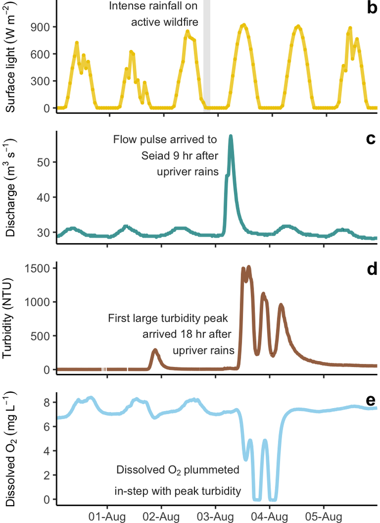

### 2.2.1 Left panels, time series of light, flow, turb and metabolism

```
[1] Before After
Levels: Before After
```

### 2.2.2 Calc mean here:

This is just raw data means–not sure why I did this here. I have a table of the means from the model that were calc in the Stats script.

```
# A tibble: 12 × 5
   var         fire      mean   lower   upper
   <chr>       <fct>    <dbl>   <dbl>   <dbl>
 1 ER          Before  -7.46   -7.71   -7.21
 2 ER          After   -3.81   -4.03   -3.60
 3 GHI.day     Before 207.    202.    213.
 4 GHI.day     After  187.    177.    196.
 5 GPP         Before   8.70    8.43    8.96
 6 GPP         After    3.29    3.05    3.53
 7 NEP         Before   1.75    1.63    1.88
 8 NEP         After   -0.503  -0.658  -0.347
 9 SV.cms      Before  55.1    53.0    57.3
10 SV.cms      After   60.6    56.3    64.9
11 turb_median Before   3.69    3.52    3.86
12 turb_median After   18.2    12.6    23.7
```

### 2.2.3 Right panel, means and laying out the final plot

The data frames for this plot are in the “Stats_D1_Report.qmd” Script. This plot will not run here without running the models in the Stats script first. Need to run these in unison, but the script is long and the model takes a while to run so I didn’t want it to clutter this script.

## 2.3 Figure 3

### 2.3.1 Figure 3 panel A: Turbidity by discharge

- Run the model
- Then, run the figure (next code chunk)

Not a variable slope/variable intercept (this is a random effect with groups) like I originally coded it; what we have is an interaction model (outcomes changed little, but good to use the correct model structure).

$$T = \beta_0 + \beta_1 \times F + \beta_2 \times Q + \beta_3 \times F \times Q + \epsilon$$

### 2.3.2 Figure 3 Panel E

- This is the GLM segmented (breakpoint) model
- This figure will not run without the model being run in the Stats script
- Prediction lines are for Jan and July conditions, based on pre and post fire years

#### 2.3.2.1 GLM model for turb to DO

- Additional model specs are in the Models script
- Running this here allows the plot below to render using just this script

#### 2.3.2.2 Break point plot

### 2.3.3 Figure 3 panes B-D, and final layout

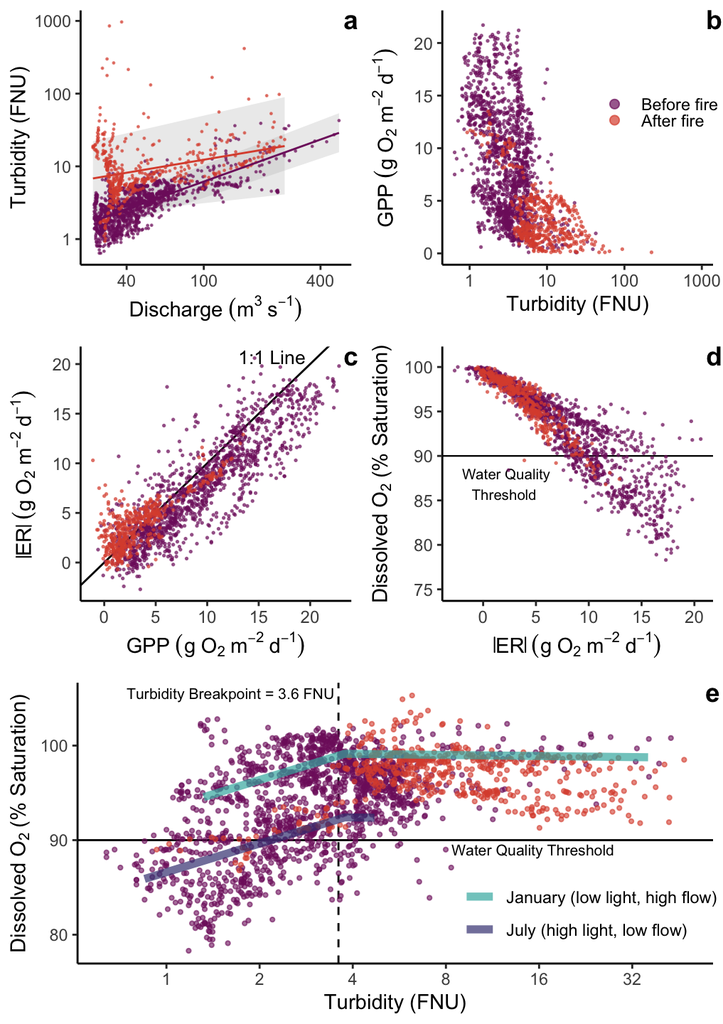

# 3 Suppliment Figures

Figures S1 and S2 were pulled from the depth script and the metabolism output script.

## 3.1 Figure S3: Full metab data set

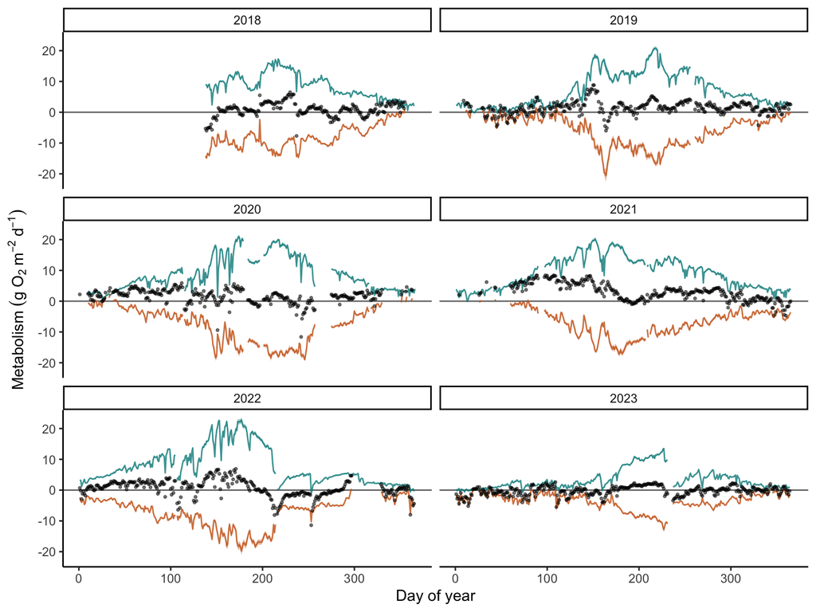

## 3.2 Figure S4: full metab data set for the ~month around the time of the fire

2 wks before and 2 wks after fire

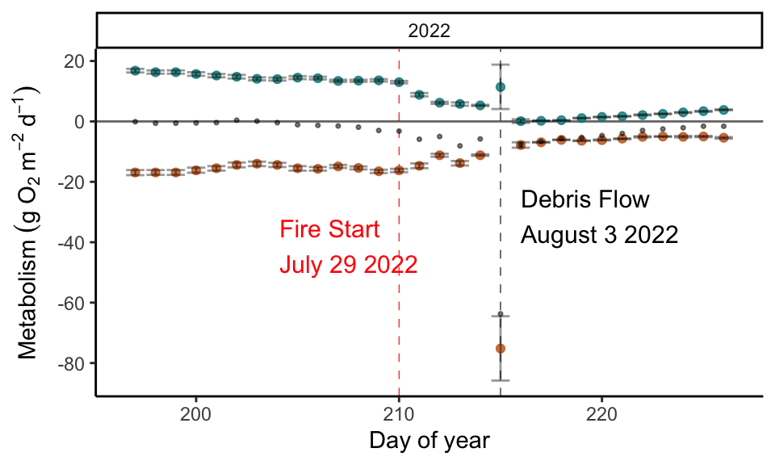

## 3.3 Figure S5 GPP x ER

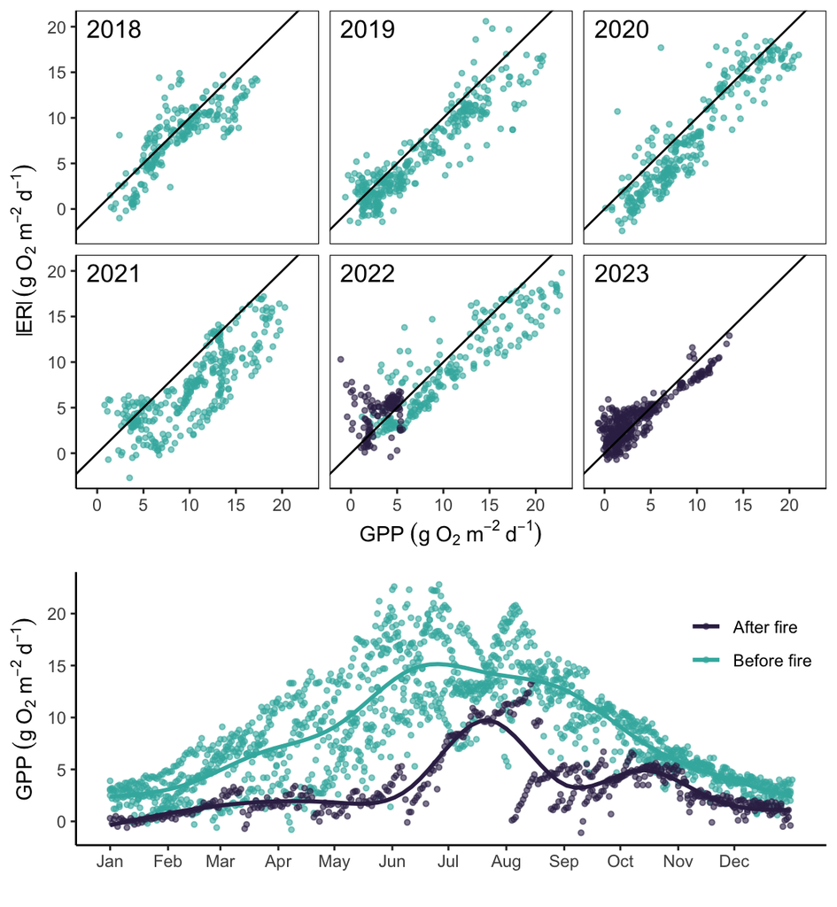

## 3.4 Figure S6: DO during turbidity spikes

### 3.4.1 Middle panel: show the Turb spikes post fire

- Panel showing daily median turbidity following the fire
- Numbers show spikes over 50; these are the “events”
- Post processed number placement in pdf editor

### 3.4.2 And the DO plots for each “event”

#### 3.4.2.1 Data prep first

- There are two sets of plots
- One goes above the turbidity time series, one below
- Plots were a total hack to get turbidity and DO on same panel
- I had to select the “windows”–3 days–of high turbidity events
- Then, select the hourly data from the metab model output
- And, the turbidity sub-daily data

#### 3.4.2.2 Set of 4 top panels:

#### 3.4.2.3 Set of 4 bottom panels:

#### 3.4.2.4 Put all plots together for this overly complex figure

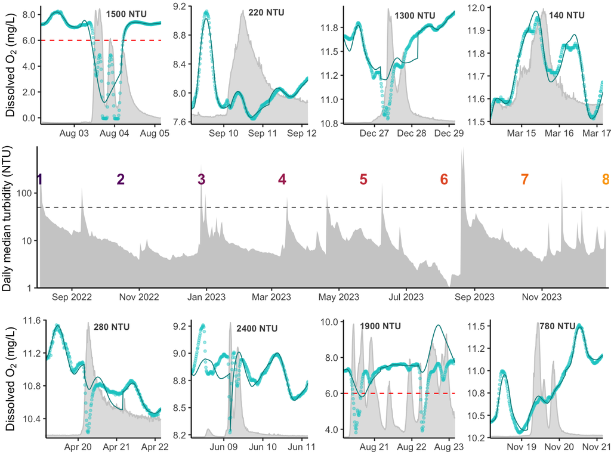

## 3.5 Figure S7: GPP by Flow, Turb, and LIght

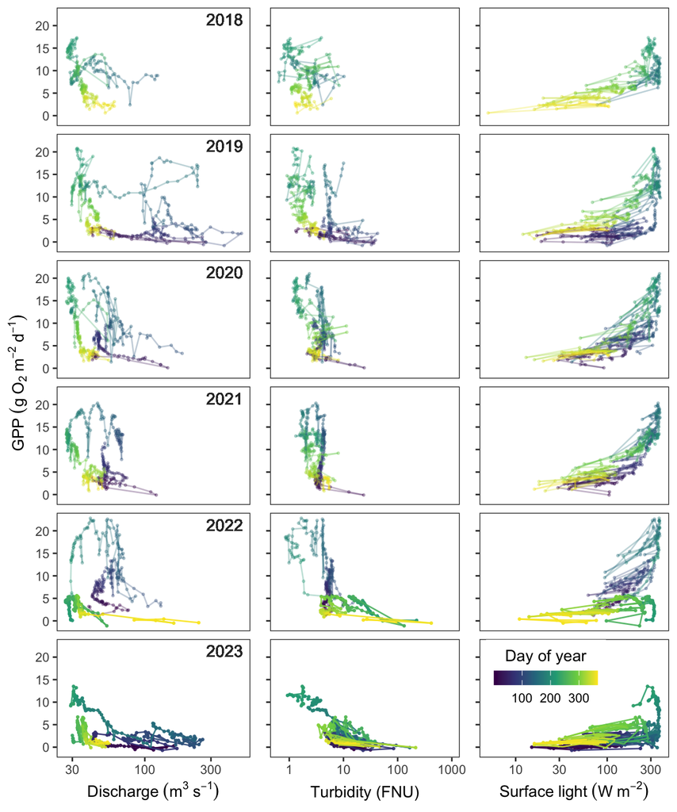

## 3.6 Figure S8: DO min and MEtabolism

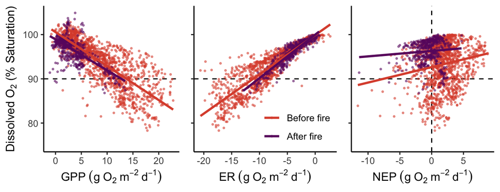